# ETC3250/5250 IML Asignment 3

Yunzhi Chen (32051018)

2023-05-15

```r
# Load the packages that you will use to complete this assignment.
library(tidyverse)
library(ggdendro)
library(patchwork)
library(rsample)
library(kknn)
library(ranger)
library(yardstick)
```

## Preliminary analysis

### Question 1

The letter in my data is A.

### Question 2

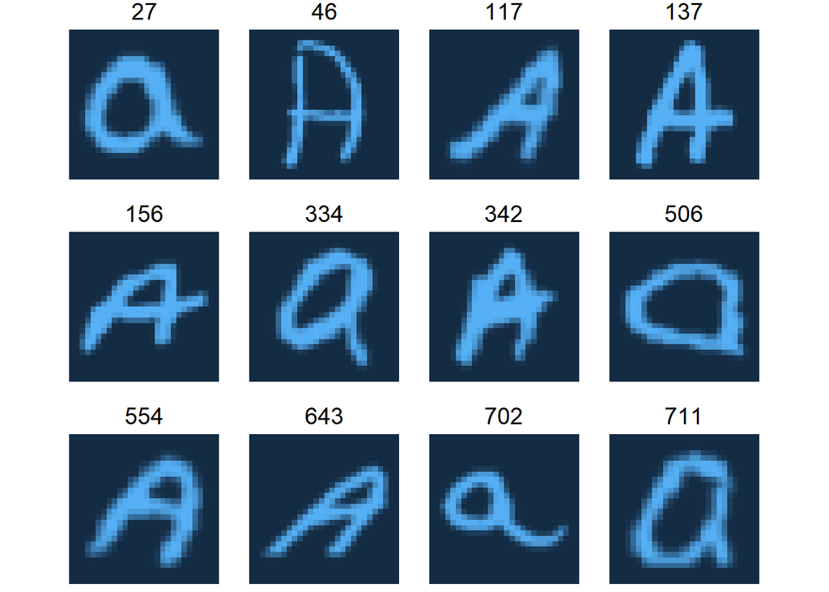

```r
images <- read_csv(here::here("data32051018.csv"))

imagedata_to_plotdata <- function(data = images,
                                  w = 28,
                                  h = 28,
                                  which = sample(1:784, 12)){
  data %>%
  mutate(id = 1:n()) %>%
  filter(id %in% which) %>%
  pivot_longer(starts_with("V")) %>%
  mutate(col = rep(rep(1:w, each = h), n_distinct(id)),
         row = rep(rep(1:h, times = w), n_distinct(id)))

}

letters <- imagedata_to_plotdata(images) %>%
  ggplot(aes(col, row)) +
  geom_tile(aes(fill = value)) +
  facet_wrap(~ id, nrow = 3) +
  scale_y_reverse() +
  theme_void(base_size = 18) +
  guides(fill = "none") +
  coord_equal()

letters
```

### Question 3

```r
images_pca <- prcomp(images,
                     rank. = 5)
summary(images_pca)
```

```
## Importance of first k=5 (out of 784) components:
##                             PC1       PC2       PC3       PC4       PC5
## Standard deviation     760.2898 631.04442 487.17223 462.35928 422.99764
## Proportion of Variance   0.1411   0.09722   0.05794   0.05219   0.04368
## Cumulative Proportion    0.1411   0.23833   0.29628   0.34846   0.39215
```

The summary shows that the first 5 principal components explain 39.22% of the variation in the data.

### Question 4

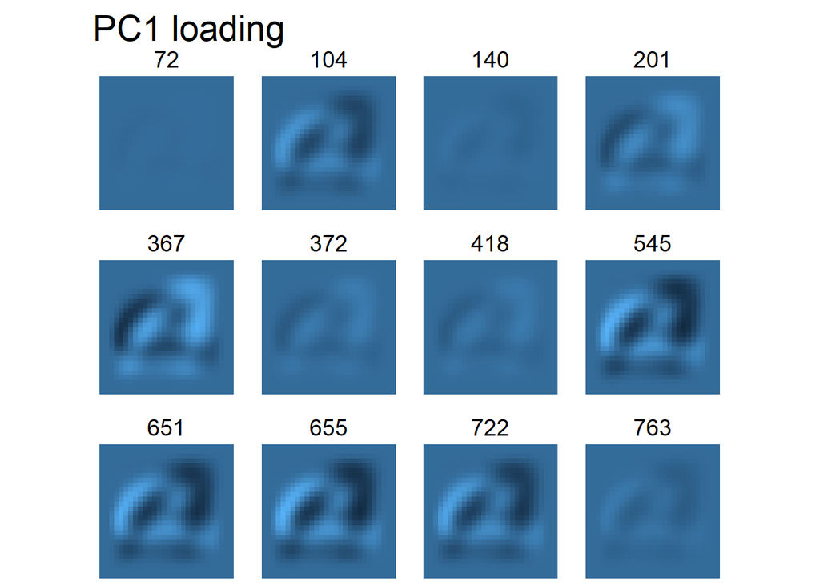

```r
sample_ids <- sample(1:784, 12)

pc_decompose <- function(k) {
    Xnew <- images_pca$x[, k, drop = FALSE] %*% t(images_pca$rotation[, k, drop = FALSE])
  rawdata <- imagedata_to_plotdata(which = sample_ids)
  as.data.frame(Xnew) %>%
    imagedata_to_plotdata(which = sample_ids)
}

letters %+% pc_decompose(1) + labs(title = "PC1 loading")
```

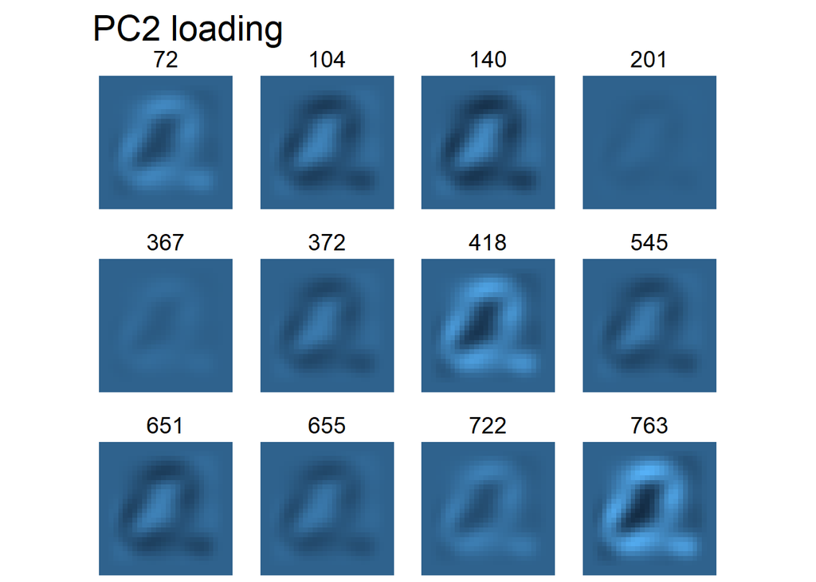

```r
letters %+% pc_decompose(2) + labs(title = "PC2 loading")
```

### Question 5

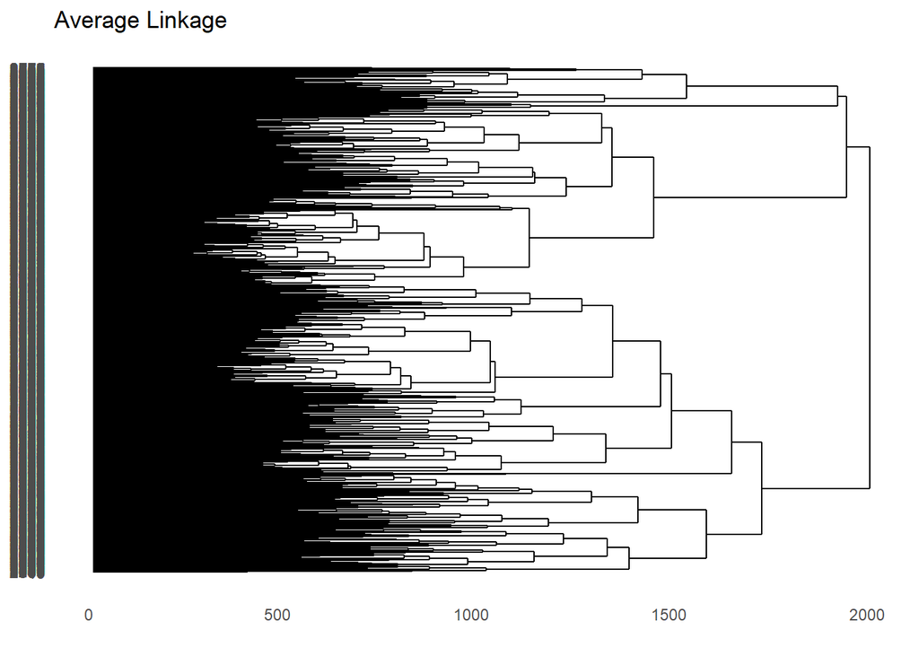

```r
haverage <- hclust(dist(images_pca$x), method = "average")

ggdendrogram(haverage, rotate = TRUE) + labs(title = "Average Linkage")
```

### Question 6

```r
caverage <- cutree(haverage, k = 4)
caverage
```

[output not shown]

[output cut: 77 more lines]

```r
table(caverage)
```

```
## caverage
##    1    2    3    4
## 1931  241 1185   34
```

### Question 7

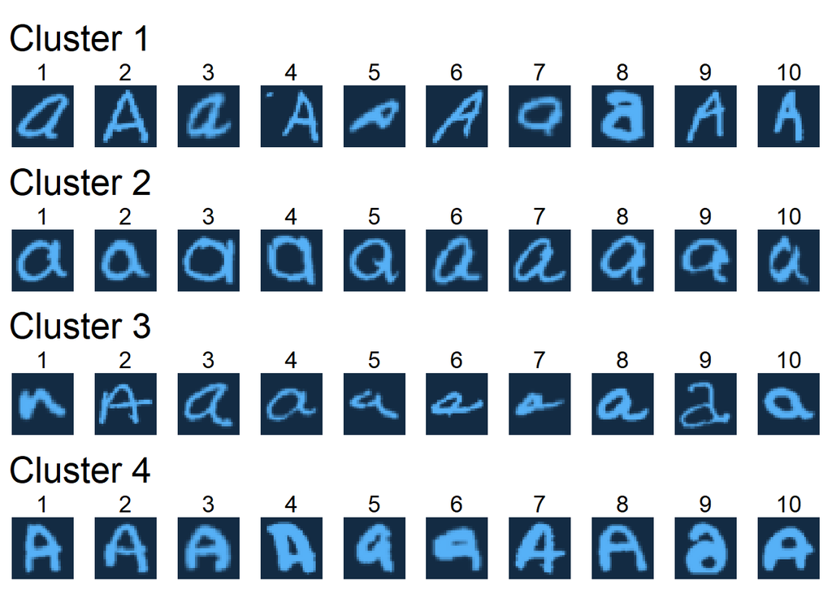

```r
view_cluster <- function(k) {
  cluster <- images %>%
    mutate(group = caverage) %>%
    filter(group == k) %>%
    imagedata_to_plotdata(which = 1:10)

  letters %+% cluster
}

cluster1 <- view_cluster(1) + labs(title = "Cluster 1") +
  facet_wrap(~ id, nrow = 1)
cluster2 <-view_cluster(2) + labs(title = "Cluster 2") +
  facet_wrap(~ id, nrow = 1)
cluster3 <-view_cluster(3) + labs(title = "Cluster 3") +
  facet_wrap(~ id, nrow = 1)
cluster4 <-view_cluster(4) + labs(title = "Cluster 4") +
  facet_wrap(~ id, nrow = 1)

cluster1/cluster2/cluster3/cluster4
```

- Cluster 1 is a mix of Uppercase “A” and lowercase “a”.
- Cluster 2 is mainly the lowercase Roman letter “a” and each letter has almost a similar shape!
- Cluster 3 seems basically consist of lower case of “a” of Roman alphabet but different written form from cluster2.
- Cluster 4 is mostly capital “A” except three.

## Report

### Group dividing

```r
set.seed(32051018)
```

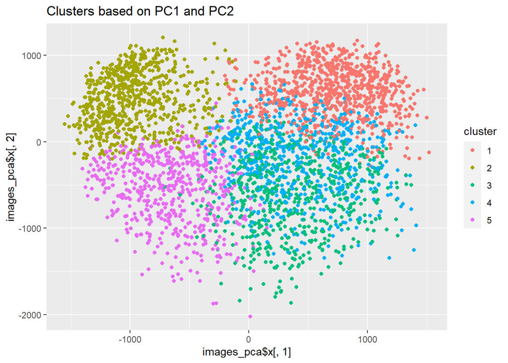

```r
# All R code in the report section should include `class.source = 'fold-hide'` in the chunk like this one
kout <- kmeans(images_pca$x, centers = 5)

# Assign each image to a cluster
images_clustered <- images %>%
  mutate(cluster = as.factor(kout$cluster))

# Visualize the clusters
ggplot(images_clustered, aes(x = images_pca$x[,1], y = images_pca$x[,2], color = cluster)) +
  geom_point() +
  labs(title = "Clusters based on PC1 and PC2")
```

By using k-means method to come up with a sensible set of groups based on the principal components of the main data. And mutate a new column to indicate each image to which cluster it belongs.

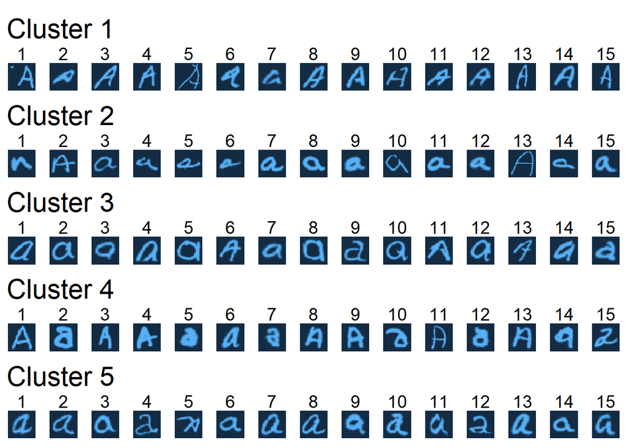

```r
view_cluster_kmeans <- function(k) {
  cluster <- images_clustered %>%
    filter(cluster == k) %>%
    imagedata_to_plotdata(which = 1:15)

 letters %+% cluster
}

cluster5 <- view_cluster_kmeans(1) + labs(title = "Cluster 1") +
  facet_wrap(~ id, nrow = 1)
cluster6 <- view_cluster_kmeans(2) + labs(title = "Cluster 2") +
  facet_wrap(~ id, nrow = 1)
cluster7 <- view_cluster_kmeans(3) + labs(title = "Cluster 3") +
  facet_wrap(~ id, nrow = 1)
cluster8 <- view_cluster_kmeans(4) + labs(title = "Cluster 4") +
  facet_wrap(~ id, nrow = 1)
cluster9 <- view_cluster_kmeans(5) + labs(title = "Cluster 5") +
  facet_wrap(~ id, nrow = 1)

cluster5/cluster6/cluster7/cluster8/cluster9
```

The view of each 5 clusters indicates that cluster 1 is composed of the capital Roman letter “A”, possessing a sharp stroke and a slant to the right.

The second cluster is mostly occupied by the lowercase form of “a”, and the shape of the lowercase is flattest compared with other clusters. And the small number of capital “A” that appear in this cluster have thinner strokes.

Cluster 4 consists of a mixture of upper and lower case letters, and the letters are scribbled in a free form.

Clusters 3 and 5 are mainly composed of the lowercase form of “a”, but contain different forms of it, a flatter shape in cluster 5. The basic writing style of cluster 3 is that the last stroke faces to the right, and some of the whole letters are tilted to the right. In total, it seems that the strokes of all letters are thinner for the last cluster.

### Supervised learning

As for the supervised learning with principal components as predictors to classify these 5 observations, I choose the kNN method and random forest method to manipulate.

```r
images_train <- as_tibble(images_pca$x) %>% mutate(cluster = as.factor(kout$cluster))
newdata <- read_csv(here::here("newrecords32051018.csv"))
test_pca <- prcomp(newdata)
images_test <- as_tibble(test_pca$x)
```

Next, using the kNN method to predict the 5 observations and produce the predict cluster of each observation:

```r
knn_pred <- kknn(cluster ~ .,
                 train = images_train,
                 test = images_test,
                 k = 2,
                 distance = 2)

prediction1 <- newdata %>%
  mutate(pred_cluster = knn_pred$fitted.values)

as_tibble(prediction1 %>% select(pred_cluster))
```

```
## # A tibble: 5 x 1
##   pred_cluster
##   <fct>
## 1 2
## 2 4
## 3 1
## 4 5
## 5 3
```

[figure not shown]

```r
imagedata_to_plotdata_new <- function(data = newdata,
                                      w = 28,
                                      h = 28,
                                      which = sample(1:5, 5)){

  data %>%
  mutate(id = 1:n()) %>%
  filter(id %in% which) %>%
  pivot_longer(starts_with("V")) %>%
  mutate(col = rep(rep(1:w, each = h), n_distinct(id)),
         row = rep(rep(1:h, times = w), n_distinct(id)))

}

letters_new <- imagedata_to_plotdata_new(newdata) %>%
  ggplot(aes(col, row)) +
  geom_tile(aes(fill = value)) +
  facet_wrap(~ id, nrow = 3) +
  scale_y_reverse() +
  theme_void(base_size = 18) +
  guides(fill = "none") +
  coord_equal()

view_cluster_knnpred <- function(k) {
  cluster <- prediction1 %>%
    filter(pred_cluster == k) %>%
    imagedata_to_plotdata_new(which = 1:5)

 letters_new %+% cluster
}


cluster10 <- view_cluster_knnpred(1) + labs(title = "Cluster 2") +
  facet_wrap(~ id, nrow = 1)
cluster11 <- view_cluster_knnpred(2) + labs(title = "Cluster 4") +
  facet_wrap(~ id, nrow = 1)
cluster12 <- view_cluster_knnpred(3) + labs(title = "Cluster 1") +
  facet_wrap(~ id, nrow = 1)
cluster13 <- view_cluster_knnpred(4) + labs(title = "Cluster 5") +
  facet_wrap(~ id, nrow = 1)
cluster14 <- view_cluster_knnpred(5) + labs(title = "Cluster 3") +
  facet_wrap(~ id, nrow = 1)
cluster10/cluster11/cluster12/cluster13/cluster14
```

As we can see from the table, the predicted cluster of the 5 observations is 2, 4, 1, 5, and 3 respectively. After a view_cluster function, we can plot the specific images of each observation.

We then fit a random forest model to the pca data and create the new column of the predicted cluster, plot by using the same view_cluster function:

```r
model_rf <- ranger(cluster ~ .,
                   data = images_train,
                   mtry = floor((ncol(images_train) - 1) / 3),
                   importance = "impurity",
                   num.trees = 500,
                   classification = TRUE)

rf_pred <- images_test %>% predict(model_rf, .)

prediction2 <- newdata %>%
  mutate(pred_cluster = rf_pred$predictions)

as_tibble(prediction2 %>% select(pred_cluster))
```

```
## # A tibble: 5 x 1
##   pred_cluster
##   <fct>
## 1 2
## 2 4
## 3 1
## 4 5
## 5 3
```

[figure not shown]

```r
view_cluster_rfpred <- function(k) {
  cluster <- prediction2 %>%
    filter(pred_cluster == k) %>%
    imagedata_to_plotdata_new(which = 1:5)

 letters_new %+% cluster
}

cluster15 <- view_cluster_rfpred(1) + labs(title = "Cluster 2") +
  facet_wrap(~ id, nrow = 1)
cluster16 <- view_cluster_rfpred(2) + labs(title = "Cluster 4") +
  facet_wrap(~ id, nrow = 1)
cluster17 <- view_cluster_rfpred(3) + labs(title = "Cluster 1") +
  facet_wrap(~ id, nrow = 1)
cluster18 <- view_cluster_rfpred(4) + labs(title = "Cluster 5") +
  facet_wrap(~ id, nrow = 1)
cluster19 <- view_cluster_rfpred(5) + labs(title = "Cluster 3") +
  facet_wrap(~ id, nrow = 1)

cluster15/cluster16/cluster17/cluster18/cluster19
```

From the table of predict cluster and the plot, both indicate that the two method lead to the same conclusion. And I will prefer the kNN method to be the best optimal one as k-NN can be applied to various types of data, including numerical and categorical variables. It can handle mixed data types without requiring extensive preprocessing.